Bacterial Genome Sequencing Results

# Summary

## XH254M_2

#### 2026-06-12

**Overview of assembly and annotation**

- This is a [circos plot](https://genome.cshlp.org/content/19/9/1639) generated by [Bakta](https://www.microbiologyresearch.org/content/journal/mgen/10.1099/mgen.0.000685) (v1.11).
- It is a circular representation of all of the contigs, and contains information such as GC skew and feature location. See [Bakta’s explanation](https://github.com/oschwengers/bakta#description-1) for more detail.

[figure not shown]

# Statistics

### ONT QC stats

| Metric | Value |
| --- | --- |
| Total bp sequenced | 157,285,467 bp |
| Total number of reads | 30,070 reads |
| Longest read | 92,268 bp |
| Raw coverage | 25x |

### Assembly stats

| Contig(s) | Length (bp) | Genome size (Mb) | Topology | Coverage (x) | Species | #genes annotated |
| --- | --- | --- | --- | --- | --- | --- |
| Genome | 6178790 bp | 6.18 Mb | circular | 24.14x | Pseudomonas_E sp013179515 | 5587 genes |

**All data is contained within the accompanying folders.**

# Results

## Contig analysis

**Assembly graph**

- This is an [assembly graph](https://github.com/rrwick/Unicycler#assembly-graphs) generated by [Bandage](https://academic.oup.com/bioinformatics/article/31/20/3350/196114) (v0.8.1).
- It shows the contigs and their connections in the assembly.
- Generally, the best graph you can have for a bacterial genome is a single circle (and possibly some other circles if you have plasmids).
- If a contig is **black**, it has a relative depth of x1.
- If a contig is **red** it has a higher relative depth, suggesting it has higher abundance in the sample.

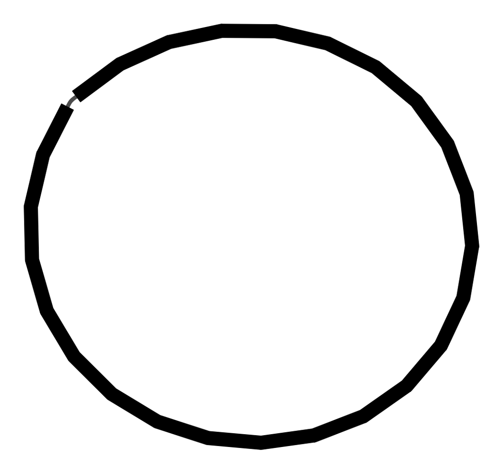

## Species analysis (Sourmash)

**Taxonomic classification**

- [Sourmash](https://sourmash.readthedocs.io/en/latest/index.html) (v5) used for k-mer–based genome content identification by comparing assemblies against a custom database (GTDB rs226, RefSeq plasmids, and phage sequences).
- ANI (Average Nucleotide Identity) represents similarity between your genome and the reference.
- The five largest contigs are shown. Classification requires the contig to match >=10% of the genome. Full Sourmash results are available in the Results Download folder.

| Contig(s) | ANI(%) | Species | Genus | Family | Order | Class | Phylum | Superkingdom |
| --- | --- | --- | --- | --- | --- | --- | --- | --- |
| Genome | 99.53 | Pseudomonas_E sp013179515 | Pseudomonas_E | Pseudomonadaceae | Pseudomonadales | Gammaproteobacteria | Pseudomonadota | Bacteria |

## Overview of sequencing reads

**Plot of all reads**

- Each **dot** on the graph represents a single read, plotted by its length and its mean [Phred quality score](https://en.wikipedia.org/wiki/Phred_quality_score).
- **Red** dots are reads *not* used the assembly.
- **Blue** dots are reads used in the assembly.
- The histograms along the top and right show the distribution of read lengths and Phred scores, respectively.
- `median phred` line shows the median Phred score of all of the reads used in the assembly.

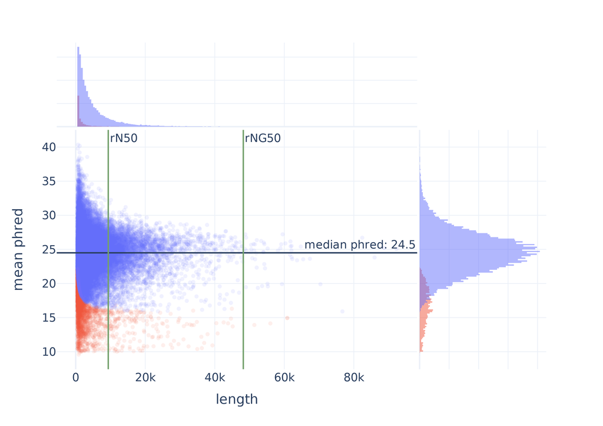

| rN50 | rNG50 |
| --- | --- |
| 9,368 bp | 48,206 bp |

**What do rN50 and rNG50 mean?**

- These are assembly statistics that help assess read/assembly quality.
- **rN50** is the “reads N50”, which is defined as the shortest read that covers 50% of the total number of bases in the reads used for assembly. [This](https://www.molecularecologist.com/2017/03/29/whats-n50/) is a good reference for better understanding N50, though note that we are reporting rN50 which uses reads instead of contigs.
- **rNG50** is the “*genome* reads N50”. We made this statistic up! However, it’s analogous to a NG50, which takes into account the known or estimated genome size. After assembly, we use the genomic length information to calculate the length where half of the genome is covered by reads of this length or longer.

## Assembly completeness

### CheckM

✅ **Your genome assembly passed the reference gene check.**

**Is the assembly complete?**

- [CheckM](https://genome.cshlp.org/content/25/7/1043) (v1.2.2) assesses the quality of genome assemblies. It uses a set of reference gene profiles to assess the completeness, contamination, and strain heterogeneity of a given assembly.
- This displays the contigs which the specific CheckM reference genes were found. The reference genes are almost always chromosomal, so if a contig plot shows it contains references genes, it is likely chromosomal.
- Why do my completeness and contamination numbers look slightly off?

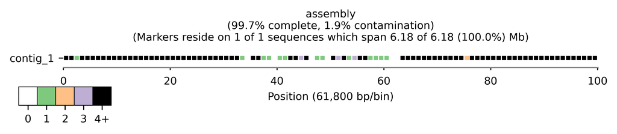

| Marker lineage | Completeness | Contamination |
| --- | --- | --- |
| g__Pseudomonas (UID4525) | 99.74 | 1.94 |

# FAQ

### Where are my FASTA files? Where are my annotated DNA sequences?

- If your sequencing run succeeded, these files can be found within the accompanying `annotation` folder, which was generated by [Bakta](https://www.microbiologyresearch.org/content/journal/mgen/10.1099/mgen.0.000685). Bioinformatics file extensions can be confusing and somewhat inconsistent. Here is a quick guide to some of file extensions you will find in your `annotation` folder:
  - FASTA files:
    - `.fna` (contig nucleotide sequences)
    - `.faa` (protein amino acid sequences)
    - `.ffn` (gene nucleotide sequences)
  - GenBank files:
    - `.gbff` (annotated contig sequences)
- You should be able to open any of these files in your favorite sequence editor (e.g.: Geneious, SnapGene, Benchling, MacVector, CLC, UGENE, etc.).

### What is a “contig”?

- This is a **contig**uous segment of DNA assembled from the sequencing reads. It may or may not represent an entire genome or entire plasmid. Generally, if your assembly graph is solely comprised of circles, each contig represents a single genome or plasmid.

### My assembly graph is *not* a circle – why does it look like a complete mess?

- If your plot is not a circle and has a more complicated path, this could be due to several reasons, including:
  - Your DNA sample was degraded and there were not enough longer reads to bridge repetitive regions (investigate your reads to assess). [Check out our guide](https://www.plasmidsaurus.com/static/img/bacteria.pdf) on preparing bacterial DNA samples for sequencing. This is the most likely cause.
  - Your genome is incredibly repetitive due to IS elements or other genomic features.
  - Your genome was very large and there were not enough reads to satisfactorily cover the genome.
  - You had a contaminant organism which reduced the overall genome coverage.

### My genome looks good, but why is CheckM reporting only 98% complete and 3% contamination?

- While CheckM is a fantastic tool, it rarely scores genomes as 100% complete with 0% contamination, even when run on “perfect” genomes. Biology is weird, and the supposedly single-copy genes that CheckM looks for may be legitimately missing or duplicated leading to slightly erroneous results.
- Some of the discrepancies may be explained by small errors in the assembly process (see below), but it is more likely that the above is causing the discrepancy.

### My contigs are circles and everything looks good – is my genome assembly perfect?

- It’s possible! However, it’s more likely that your genome assembly still contains SNPs (single nucleotide polymorphisms), especially in regions where ONT reads have higher error rates, such as long homopolymers. It’s also possible, though less likely than SNPs, that your genome assembly contains medium-sized structural errors ([e.g.: deleting 50 bp from the end of a contig](https://github.com/rrwick/Trycycler/wiki)). For the very best possible assembly, we recommend trying your hand at using [Trycycler](https://genomebiology.biomedcentral.com/articles/10.1186/s13059-021-02483-z) to assemble your genomes and polishing with Illumina reads. Trycycler is a manual pipeline and can be quite labor intensive. While very high quality, the genome assemblies we return should be treated as draft assemblies.

### How do I interpret the polished stats file?

The `{sample}_polished-stats.txt` file shows position-by-position information about how Polypolish processed your assembly. Here’s what the columns mean:

#### **Key Columns**

- **name**: Contig name
- **pos**: Position in the contig
- **base**: Original base from the long-read assembly
- **depth**: Average read depth at this position
- **valid**: Number of valid short reads covering this position
- **pileup**: Base composition from short reads (e.g., “Tx258” means 258 T’s)
- **status**: Polypolish’s decision for this position
- **new_base**: Final base in the polished assembly

#### **Status Meanings**

- **kept**: Original base was retained (one valid option which matches the assembly base)
- **changed**: Base was changed based on short read consensus (one valid option which differs from the assembly base)
- **too_close**: Position too close to another position that was polished (one or more options are neither valid nor invalid)
- **multiple**: Multiple possible corrections (ambiguous; more than one valid option)
- **low_depth**: Insufficient short read depth (below `--min_depth`)
- **none**: no valid options

### How is the assembly generated?

1. Remove the bottom 5% worst fastq reads via Filtlong v0.2.1 (default parameters)
2. Estimate genome size using Autocycler helper functions
3. Generate multiple subsampled read sets using Autocycler with optimal coverage for each subsample
4. Perform multiple assemblies using Autocycler with three different assemblers:
   - [Flye](https://www.nature.com/articles/s41587-019-0072-8) v2.9.6+ with parameters optimized for high quality ONT reads
   - [Hifiasm](https://github.com/chhylp123/hifiasm) for generating high-quality assemblies from long reads
   - [Plassembler](https://github.com/gbouras13/plassembler) v1.8.0+ for detecting and assembling plasmids
5. Remove low depth and small contigs and then compress, cluster, trim, resolve, and clean assemblies using Autocycler to identify the best consensus assembly from all assemblers
6. Rotate the assembly to start at the optimal position using dnaapler
7. Polish the consensus assembly via [Medaka](https://github.com/nanoporetech/medaka) v1.8.0 using the filtered reads

### How is the polished assembly generated?

1. **Quality Control**: Short reads are processed using fastp with quality filtering (Phred ≥15, length ≥50bp, adapter trimming, poly-G trimming)
2. **Alignment**: Quality-controlled short reads are aligned to the long-read reference assembly using bwa-mem2
3. **Polishing**: The long-read assembly is polished using Polypolish with the aligned short reads
   - Uses `--careful` mode when coverage < 25x